| title: “Basic data analyses with R” |
| --- |
| author: “Christophe Pallier” |
| date: “6/12/2019” |
| output: |
| html_document: |
| toc: true |
| toc_depth: 2 |

# Comparing two proportions (binary response)

A binary variable `resp` has been measured in two independent groups (no matching).

We therefore have four counts.

We first put them into a table.

```r
dat <- as.table(matrix(c(40, 20,
                         50, 40),
                       nrow=2,
                       byrow=T,
                       dimnames=list(group=c('Gr1', 'Gr2'),
                                    resp=0:1)))
dat
```

```
##      resp
## group  0  1
##   Gr1 40 20
##   Gr2 50 40
```

Note: There may a better/simpler way to create a table… If you know one, please let me know.

Now we can obtain the proportions in each group:

```r
signif(prop.table(dat, 1), 2)
```

```
##      resp
## group    0    1
##   Gr1 0.67 0.33
##   Gr2 0.56 0.44
```

And plot the table:

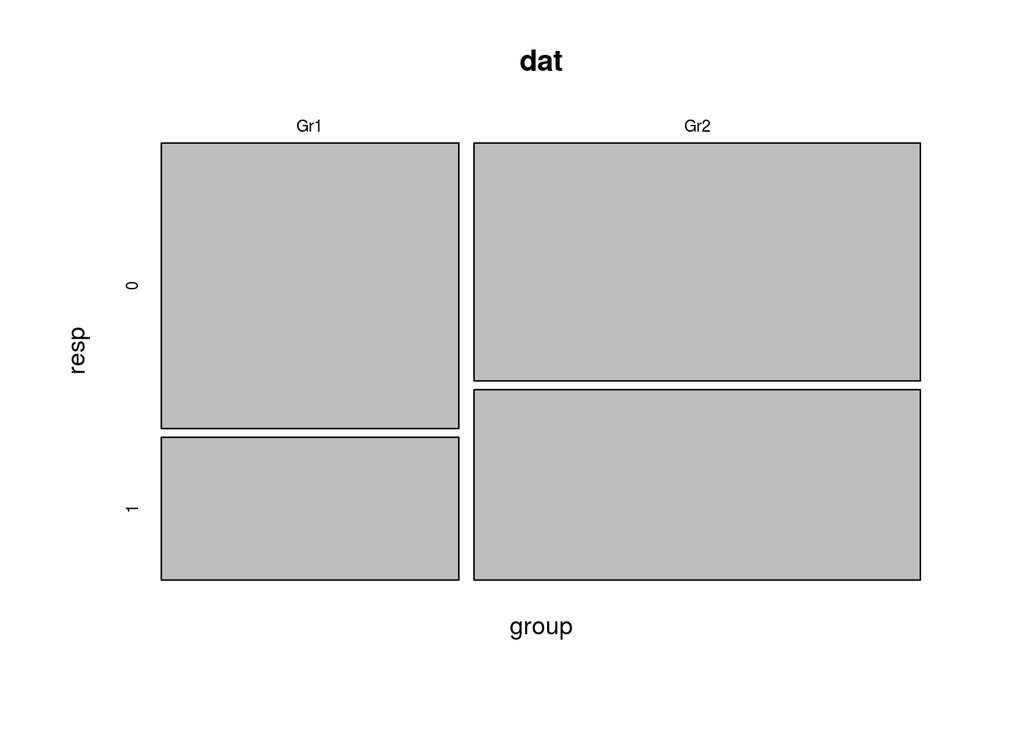

```r
plot(dat)
```

If you do not like the mosaicplot, you can use a barplot

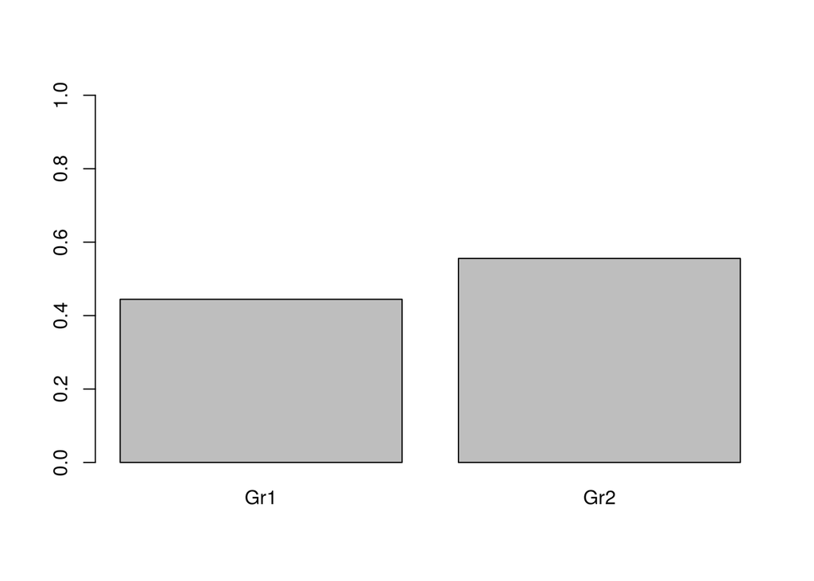

```r
barplot(prop.table(dat[,1]), ylim=c(0,1))
```

Then we compute inferential stats to see if we can reject the null hypothesis that the two samples come from populations with identical proportions.

If no cell is less than 5, a Pearson’s $\Chi^2$ test will do. There are many ways to perform it:

```r
chisq.test(dat)
```

```
##
##  Pearson's Chi-squared test with Yates' continuity correction
##
## data:  dat
## X-squared = 1.4178, df = 1, p-value = 0.2338
```

```r
prop.test(dat)
```

```
##
##  2-sample test for equality of proportions with continuity
##  correction
##
## data:  dat
## X-squared = 1.4178, df = 1, p-value = 0.2338
## alternative hypothesis: two.sided
## 95 percent confidence interval:
##  -0.06015188  0.28237410
## sample estimates:
##    prop 1    prop 2
## 0.6666667 0.5555556
```

```r
require(gmodels)
CrossTable(dat, chisq=TRUE)
```

```
##
##
##    Cell Contents
## |-------------------------|
## |                       N |
## | Chi-square contribution |
## |           N / Row Total |
## |           N / Col Total |
## |         N / Table Total |
## |-------------------------|
##
##
## Total Observations in Table:  150
##
##
##              | resp
##        group |         0 |         1 | Row Total |
## -------------|-----------|-----------|-----------|
##          Gr1 |        40 |        20 |        60 |
##              |     0.444 |     0.667 |           |
##              |     0.667 |     0.333 |     0.400 |
##              |     0.444 |     0.333 |           |
##              |     0.267 |     0.133 |           |
## -------------|-----------|-----------|-----------|
##          Gr2 |        50 |        40 |        90 |
##              |     0.296 |     0.444 |           |
##              |     0.556 |     0.444 |     0.600 |
##              |     0.556 |     0.667 |           |
##              |     0.333 |     0.267 |           |
## -------------|-----------|-----------|-----------|
## Column Total |        90 |        60 |       150 |
##              |     0.600 |     0.400 |           |
## -------------|-----------|-----------|-----------|
##
##
## Statistics for All Table Factors
##
##
## Pearson's Chi-squared test
## ------------------------------------------------------------
## Chi^2 =  1.851852     d.f. =  1     p =  0.1735682
##
## Pearson's Chi-squared test with Yates' continuity correction
## ------------------------------------------------------------
## Chi^2 =  1.417824     d.f. =  1     p =  0.2337619
##
##
```

# Estimation - Confidence intervals

Here, we just show how to get confidence intervals for the proportion or the mean obtained from a sample. For confidence intervalle of comparisons, see the other files.

## Estimating a proportion

```r
n <- 100
a <- rbinom(n, size=1, prob=1/3)
```

```r
table(a)
```

```
## a
##  0  1
## 64 36
```

```r
prop.table(table(a))
```

```
## a
##    0    1
## 0.64 0.36
```

```r
mean(a)
```

```
## [1] 0.36
```

### Inferential stats

```r
prop.test(table(a))
```

```
##
##  1-sample proportions test with continuity correction
##
## data:  table(a), null probability 0.5
## X-squared = 7.29, df = 1, p-value = 0.006934
## alternative hypothesis: true p is not equal to 0.5
## 95 percent confidence interval:
##  0.5372745 0.7318279
## sample estimates:
##    p
## 0.64
```

```r
prop.test(table(a))$conf.int
```

```
## [1] 0.5372745 0.7318279
## attr(,"conf.level")
## [1] 0.95
```

## Estimating a mean

```r
n <- 100
a <- rnorm(n, mean=100, sd=15)
```

## Exploratory graphics

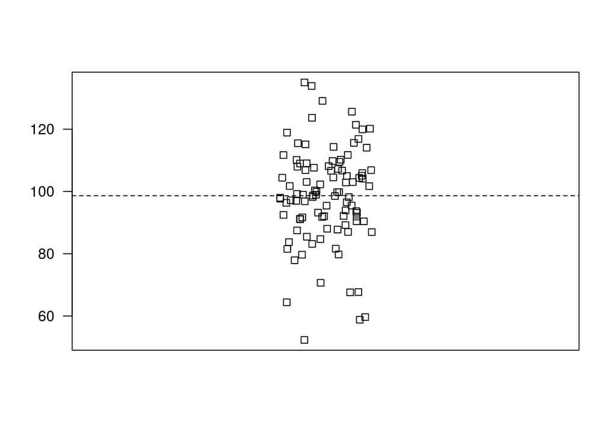

```r
par(las=1)
stripchart(a, method='jitter', vertical=TRUE)
abline(h=mean(a), lty=2)
```

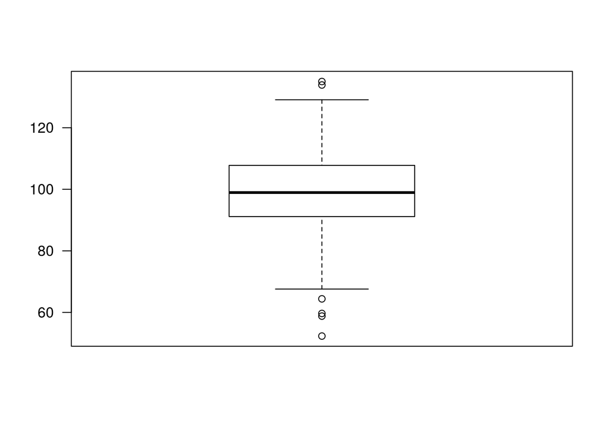

```r
boxplot(a)
```

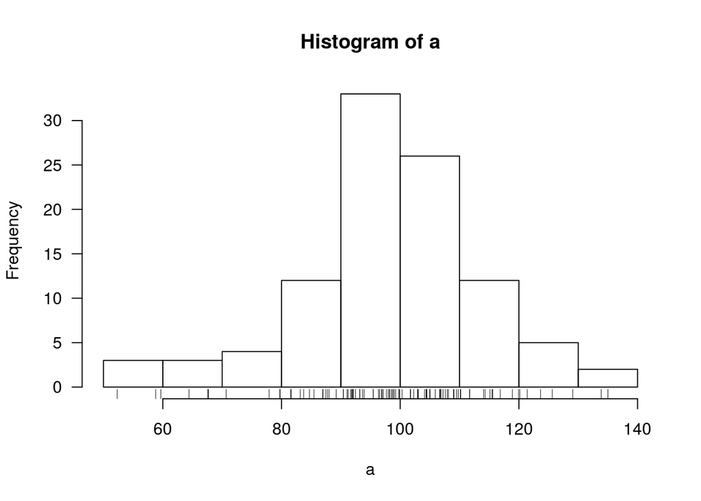

```r
hist(a)
rug(a)
```

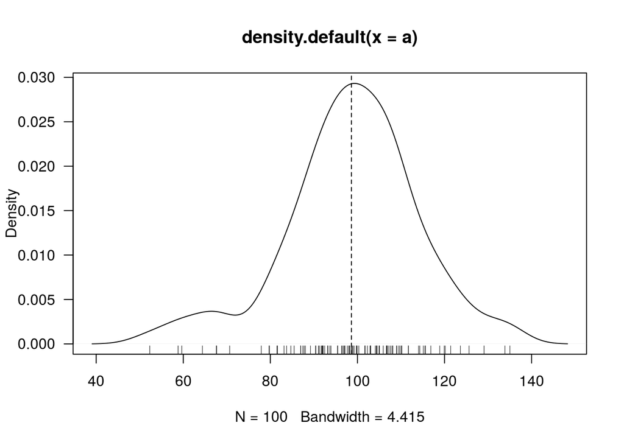

```r
plot(density(a))
abline(v=mean(a), lty=2)
rug(a)
```

If the sample is small, you can use a `dotchart`

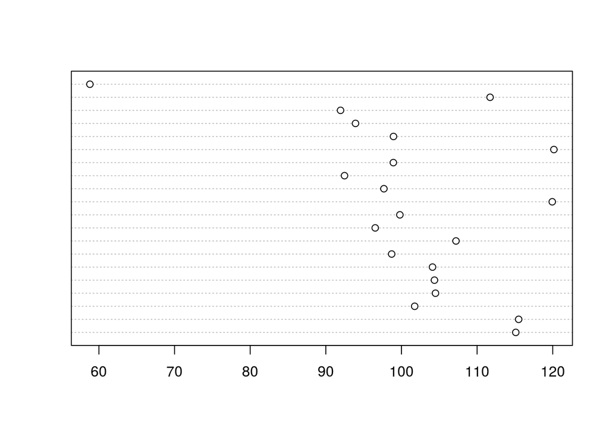

```r
dotchart(a[1:20])
```

## Descriptive stats

```r
summary(a)
```

```
##    Min. 1st Qu.  Median    Mean 3rd Qu.    Max.
##   52.32   91.18   98.94   98.61  107.69  135.00
```

```r
mean(a)
```

```
## [1] 98.61289
```

```r
mean(a[abs(a-mean(a)) < 2*sd(a)]) # after deleting point beyond 2 stddev
```

```
## [1] 100.2385
```

## Confidence intervals

```r
t.test(a)
```

```
##
##  One Sample t-test
##
## data:  a
## t = 64.108, df = 99, p-value < 2.2e-16
## alternative hypothesis: true mean is not equal to 0
## 95 percent confidence interval:
##   95.56071 101.66507
## sample estimates:
## mean of x
##  98.61289
```

```r
t.test(a)$conf.int
```

```
## [1]  95.56071 101.66507
## attr(,"conf.level")
## [1] 0.95
```

```r
require(boot)
sampmean <- function(x, d) { mean(x[d]) }
boota <- boot(a, sampmean, 1000)
boot.ci(boota)
```

```
## BOOTSTRAP CONFIDENCE INTERVAL CALCULATIONS
## Based on 1000 bootstrap replicates
##
## CALL :
## boot.ci(boot.out = boota)
##
## Intervals :
## Level      Normal              Basic
## 95%   ( 95.59, 101.51 )   ( 95.55, 101.71 )
##
## Level     Percentile            BCa
## 95%   ( 95.52, 101.68 )   ( 95.33, 101.51 )
## Calculations and Intervals on Original Scale
```

# Comparing two groups (continous dependent variable)

```r
g1 <- 500 + rnorm(30, sd=40)
g2 <- 520 + rnorm(20, sd=30)
write(g1, 'group1.dat')
write(g2, 'group2.dat')
rm(g1, g2)
```

Data for this example are in two text files `group1.dat` and `group2.dat`.

```r
g1 <- scan('group1.dat')
g2 <- scan('group2.dat')
```

We arrange them into a data frame with two columns: `group` (a factor with two modalities: `Gr1` and `Gr2`), and `y` which contains the values themselves.

```r
tg <- data.frame(group=factor(rep(c('Gr1', 'Gr2'),
                                  c(length(g1), length(g2)))),
                 y=c(g1, g2))

head(tg)
```

```
##   group        y
## 1   Gr1 484.3378
## 2   Gr1 493.6377
## 3   Gr1 561.7153
## 4   Gr1 459.4547
## 5   Gr1 446.5427
## 6   Gr1 493.2137
```

```r
str(tg)
```

```
## 'data.frame':    50 obs. of  2 variables:
##  $ group: Factor w/ 2 levels "Gr1","Gr2": 1 1 1 1 1 1 1 1 1 1 ...
##  $ y    : num  484 494 562 459 447 ...
```

```r
table(tg$group)
```

```
##
## Gr1 Gr2
##  30  20
```

### Graphical explorations

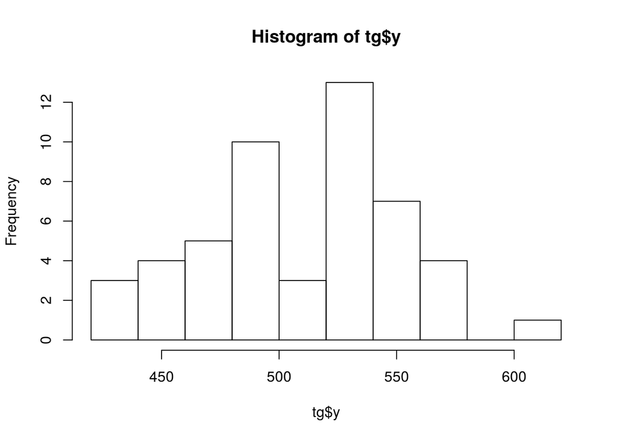

```r
hist(tg$y)
```

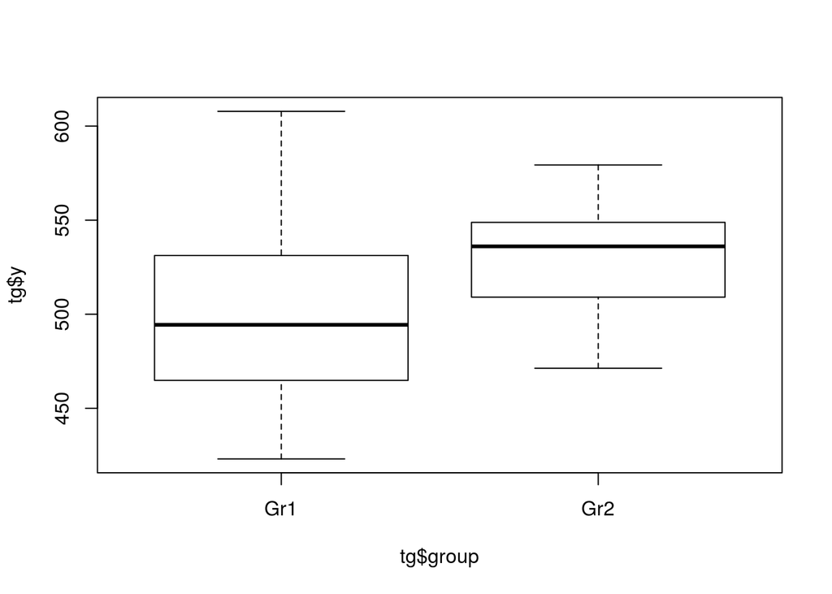

```r
boxplot(tg$y ~ tg$group)
```

When the samples are small, stripchart may be the best:

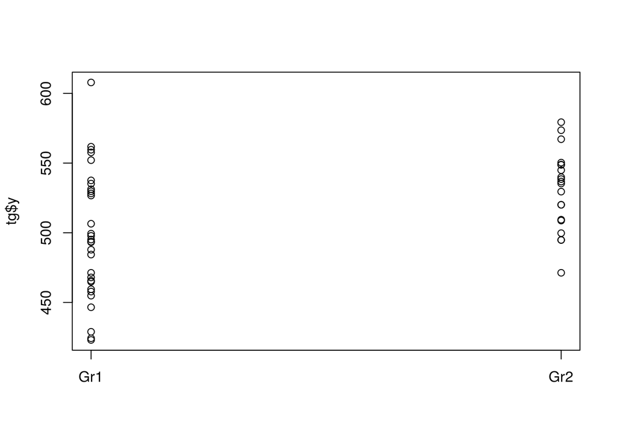

```r
stripchart(tg$y ~ tg$group,
           vertical=TRUE,
           pch=1)
```

If the samples are large enough, you can create density plots:

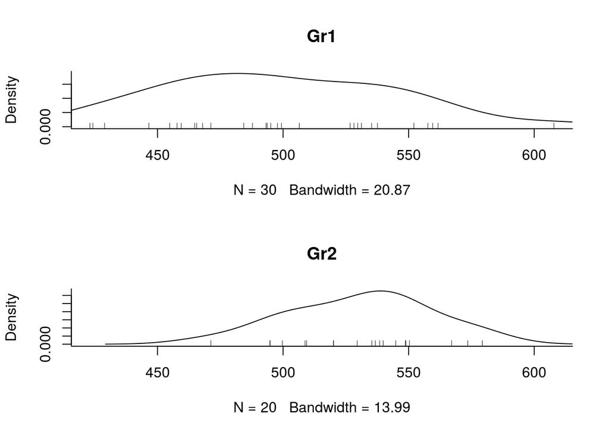

```r
par(mfrow=(c(2,1)))
xsca <- range(tg$y)
for (gr in levels(tg$group))
{
  with(subset(tg, group==gr),
       {
         plot(density(y), xlim=xsca, main=gr, bty='l')
         rug(y, ticksize=0.1)
         })
}
```

Obtain the basic descriptive stats

```r
attach(tg)
signif(tapply(y, group, mean),3)
```

```
## Gr1 Gr2
## 498 531
```

```r
signif(tapply(y, group, median), 3)
```

```
## Gr1 Gr2
## 494 536
```

```r
signif(tapply(y, group, sd), 3)
```

```
##  Gr1  Gr2
## 45.8 28.3
```

```r
signif(tapply(y, group, se), 3)
```

```
##  Gr1  Gr2
## 8.36 6.33
```

```r
detach(tg)
```

### Inferential statistics

Student T-tests. First assuming equal variance, then relaxing this assumption

```r
t.test(y ~ group, data=tg, var.equal=TRUE)
```

```
##
##  Two Sample t-test
##
## data:  y by group
## t = -2.8076, df = 48, p-value = 0.007195
## alternative hypothesis: true difference in means is not equal to 0
## 95 percent confidence interval:
##  -55.352029  -9.155198
## sample estimates:
## mean in group Gr1 mean in group Gr2
##          498.3289          530.5826
```

```r
t.test(y ~ group, data=tg)
```

```
##
##  Welch Two Sample t-test
##
## data:  y by group
## t = -3.0764, df = 47.799, p-value = 0.003462
## alternative hypothesis: true difference in means is not equal to 0
## 95 percent confidence interval:
##  -53.33609 -11.17114
## sample estimates:
## mean in group Gr1 mean in group Gr2
##          498.3289          530.5826
```

Somewhat more information can be obtained by fitting linear models.

First with a parametrisation (`contr.treatment`) of group where the intercept will correspond to the mean of group 1 and the effect will estimate the difference between the two groups.

```r
contrasts(tg$group) <- contr.treatment
contrasts(tg$group)
```

```
##     2
## Gr1 0
## Gr2 1
```

```r
summary(lm(y ~ group, data=tg))
```

```
##
## Call:
## lm(formula = y ~ group, data = tg)
##
## Residuals:
##     Min      1Q  Median      3Q     Max
## -75.240 -30.753  -0.826  29.521 109.511
##
## Coefficients:
##             Estimate Std. Error t value Pr(>|t|)
## (Intercept)  498.329      7.266  68.586  < 2e-16 ***
## group2        32.254     11.488   2.808  0.00719 **
## ---
## Signif. codes:  0 '***' 0.001 '**' 0.01 '*' 0.05 '.' 0.1 ' ' 1
##
## Residual standard error: 39.8 on 48 degrees of freedom
## Multiple R-squared:  0.1411, Adjusted R-squared:  0.1232
## F-statistic: 7.882 on 1 and 48 DF,  p-value: 0.007195
```

Alternatively, one can prefer a parametrisation where the intercept estimates the global mean and the first parameter is the deviation from the global mean.

```r
contrasts(tg$group) <- contr.sum
contrasts(tg$group)
```

```
##     [,1]
## Gr1    1
## Gr2   -1
```

```r
summary(lm(y ~ group, data=tg))
```

```
##
## Call:
## lm(formula = y ~ group, data = tg)
##
## Residuals:
##     Min      1Q  Median      3Q     Max
## -75.240 -30.753  -0.826  29.521 109.511
##
## Coefficients:
##             Estimate Std. Error t value Pr(>|t|)
## (Intercept)  514.456      5.744  89.563  < 2e-16 ***
## group1       -16.127      5.744  -2.808  0.00719 **
## ---
## Signif. codes:  0 '***' 0.001 '**' 0.01 '*' 0.05 '.' 0.1 ' ' 1
##
## Residual standard error: 39.8 on 48 degrees of freedom
## Multiple R-squared:  0.1411, Adjusted R-squared:  0.1232
## F-statistic: 7.882 on 1 and 48 DF,  p-value: 0.007195
```

### Barplot with standard errors

Barplot with the means and their associated standard errors (note this is not the standard error for the difference between the groups’ means, which is roughly $\sqrt{2}$ larger and, maybe for this reason, rarely used in psychology papers (like they rarely report confidence intervals))

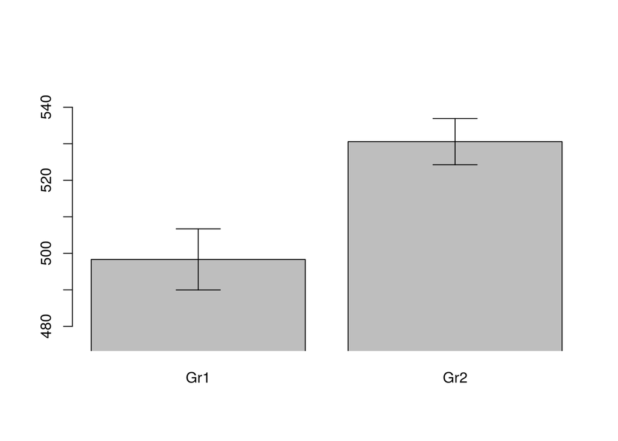

```r
attach(tg)
par(mfrow=c(1,1))
means <- tapply(y, group, mean)
ses <- tapply(y, group, se)

ysca = c(min(means - 3 * ses), max(means + 3 * ses))

mp <- barplot(means, ylim=ysca, xpd=F)
arrows(mp, means-ses,
       mp, means+ses,
       code=3, angle=90)
```

```r
detach(tg)
```

A much nicer plot can be constructed, with confidence intervals for the means and for their difference (Cumming, Geoff, and Sue Finch. 2005. “Inference by Eye: Confidence Intervals and How to Read Pictures of Data.” American Psychologist 60 (2): 170–180.)

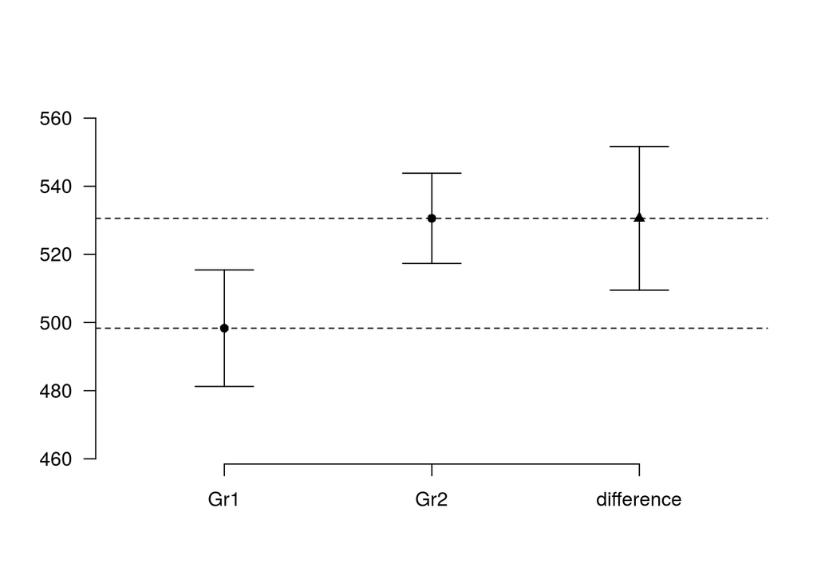

```r
attach(tg)
m1 <- t.test(y[group=='Gr1'])$conf.int
m2 <- t.test(y[group=='Gr2'])$conf.int
di <- diff(t.test(y~group)$conf.int)
ysca <- c(min(c(m1,m2)-0.3*diff(range(c(m1,m2)))),
          max(c(m1,m2)+0.3*diff(range(c(m1,m2)))))

plot(c(Gr1=1, Gr2=2, difference=3),
     c(mean(m1), mean(m2), mean(m2)),
     pch=c(16,16,17), ylim=ysca, xlim=c(.5,3.5), axes=F, xlab='', ylab='')
axis(2, las=1)
axis(1,at=1:3,labels=c('Gr1','Gr2','difference'))
arrows(1:3, c(m1[1], m2[1], mean(m2)-di/2),
       1:3, c(m1[2], m2[2], mean(m2)+di/2),
       code=3, angle=90)
abline(h=mean(m1), lty=2)
abline(h=mean(m2), lty=2)
```

```r
detach(tg)
```

# Comparison of two groups

```r
meang1 <- 100
meang2 <- 110
g1 <- meang1 + scale(rnorm(30,))*10
g2 <- meang2 + scale(rnorm(30))*10
```

```
boxplot(cbind(g1, g2))

t.test(g1, g2, var.equal=TRUE)
```

First, let us create a 2x2 design, resulting from the crossing of binary factors ‘a’ and ‘b’:

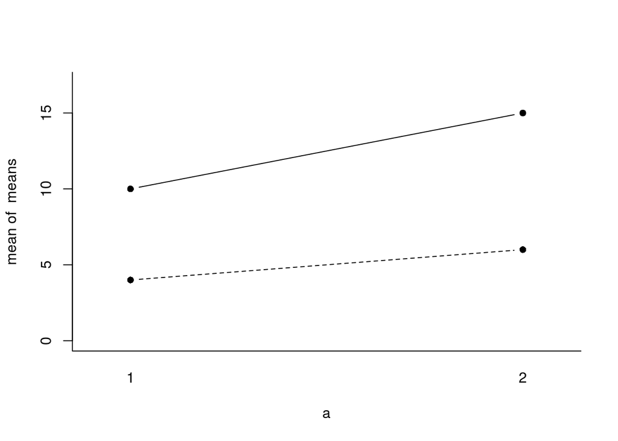

```r
a <- gl(2, 1, 4)
b <- gl(2, 2, 4)
means <- c(4, 6, 10, 15)
interaction.plot(a,b,means,ylim=c(0,17),legend=F,type='b',pch=16,bty="l")
```

First, we fit an additive model without the interaction term.

```r
tapply(means, list(a=a, b=b), mean)
```

```
##    b
## a   1  2
##   1 4 10
##   2 6 15
```

```r
diff(tapply(means, list(a), mean)) # main effect of a
```

```
##   2
## 3.5
```

```r
diff(tapply(means, list(b), mean)) # main effect of b
```

```
##   2
## 7.5
```

```r
summary(mod2<-lm(means~a+b))
```

```
##
## Call:
## lm(formula = means ~ a + b)
##
## Residuals:
##     1     2     3     4
##  0.75 -0.75 -0.75  0.75
##
## Coefficients:
##             Estimate Std. Error t value Pr(>|t|)
## (Intercept)    3.250      1.299   2.502    0.242
## a2             3.500      1.500   2.333    0.258
## b2             7.500      1.500   5.000    0.126
##
## Residual standard error: 1.5 on 1 degrees of freedom
## Multiple R-squared:  0.9682, Adjusted R-squared:  0.9046
## F-statistic: 15.22 on 2 and 1 DF,  p-value: 0.1783
```

```r
model.matrix(mod2)
```

```
##   (Intercept) a2 b2
## 1           1  0  0
## 2           1  1  0
## 3           1  0  1
## 4           1  1  1
## attr(,"assign")
## [1] 0 1 2
## attr(,"contrasts")
## attr(,"contrasts")$a
## [1] "contr.treatment"
##
## attr(,"contrasts")$b
## [1] "contr.treatment"
```

```r
model.tables(aov(means~a+b))
```

```
## Tables of effects
##
##  a
## a
##     1     2
## -1.75  1.75
##
##  b
## b
##     1     2
## -3.75  3.75
```

```r
model.tables(aov(means~a*b))
```

```
## Tables of effects
##
##  a
## a
##     1     2
## -1.75  1.75
##
##  b
## b
##     1     2
## -3.75  3.75
##
##  a:b
##    b
## a   1     2
##   1  0.75 -0.75
##   2 -0.75  0.75
```

Then, we fit a model including the interaction:

```r
par(las=1)

interaction.plot(a,b,means,ylim=c(0,17),legend=F,type='b',pch=16,bty="l")

eps=.9
text(1,4+eps,"a1b1")
text(2,6+eps,"a2b1")
text(1,10+eps,"a1b2")
text(2,15+eps,"a2b2")

lines(c(1,2),c(10,12),lty=3)

arrows(1,0,1,4, code=3,length=.1)
arrows(2,4,2,6, code=3, length=.1)
arrows(1,4,1,10, code=3, length=.1)
arrows(2,12,2,15, code=3, length=.1)


mod1 = lm(means~a*b)
model.matrix(mod1)
```

```
##   (Intercept) a2 b2 a2:b2
## 1           1  0  0     0
## 2           1  1  0     0
## 3           1  0  1     0
## 4           1  1  1     1
## attr(,"assign")
## [1] 0 1 2 3
## attr(,"contrasts")
## attr(,"contrasts")$a
## [1] "contr.treatment"
##
## attr(,"contrasts")$b
## [1] "contr.treatment"
```

```r
summary(mod1)
```

```
##
## Call:
## lm(formula = means ~ a * b)
##
## Residuals:
## ALL 4 residuals are 0: no residual degrees of freedom!
##
## Coefficients:
##             Estimate Std. Error t value Pr(>|t|)
## (Intercept)        4         NA      NA       NA
## a2                 2         NA      NA       NA
## b2                 6         NA      NA       NA
## a2:b2              3         NA      NA       NA
##
## Residual standard error: NaN on 0 degrees of freedom
## Multiple R-squared:      1,  Adjusted R-squared:    NaN
## F-statistic:   NaN on 3 and 0 DF,  p-value: NA
```

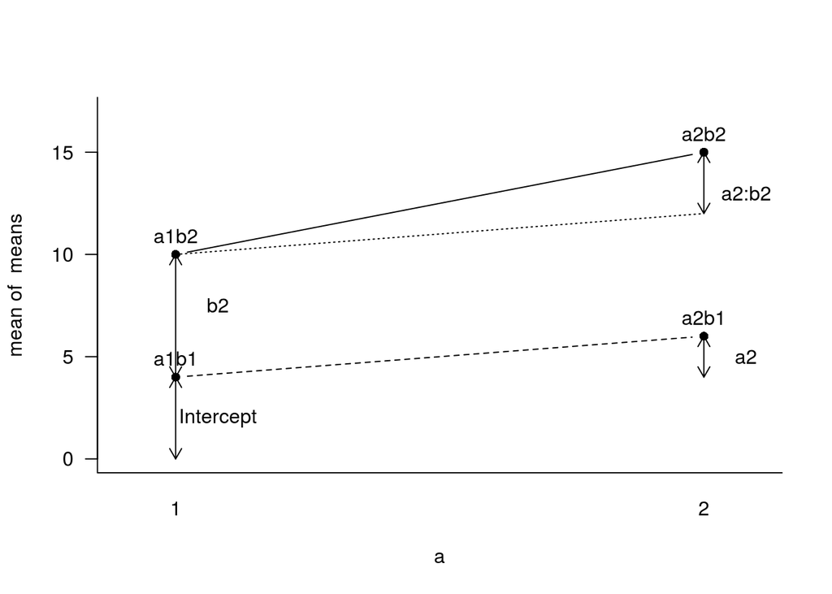

```r
text(1.08,2,"Intercept") # intercept
text(2.08,5,"a2") # a2
text(1.08,7.5,"b2") # b2
text(2.08,13,"a2:b2") # a2:b2
```

# Comparing the means of several independent groups

Data are in a spreasheet format, in `oneway.csv`

```r
ow <- read.csv('oneway.csv')
head(ow)
```

```
##   X group        y
## 1 1   Gr1 3.627371
## 2 2   Gr1 3.228733
## 3 3   Gr1 3.430202
## 4 4   Gr1 3.423740
## 5 5   Gr1 2.838726
## 6 6   Gr1 2.275258
```

```r
str(ow)
```

```
## 'data.frame':    288 obs. of  3 variables:
##  $ X    : int  1 2 3 4 5 6 7 8 9 10 ...
##  $ group: Factor w/ 5 levels "Gr1","Gr2","Gr3",..: 1 1 1 1 1 1 1 1 1 1 ...
##  $ y    : num  3.63 3.23 3.43 3.42 2.84 ...
```

We can perform the same operations as we did for the two samples case.

### Graphical explorations

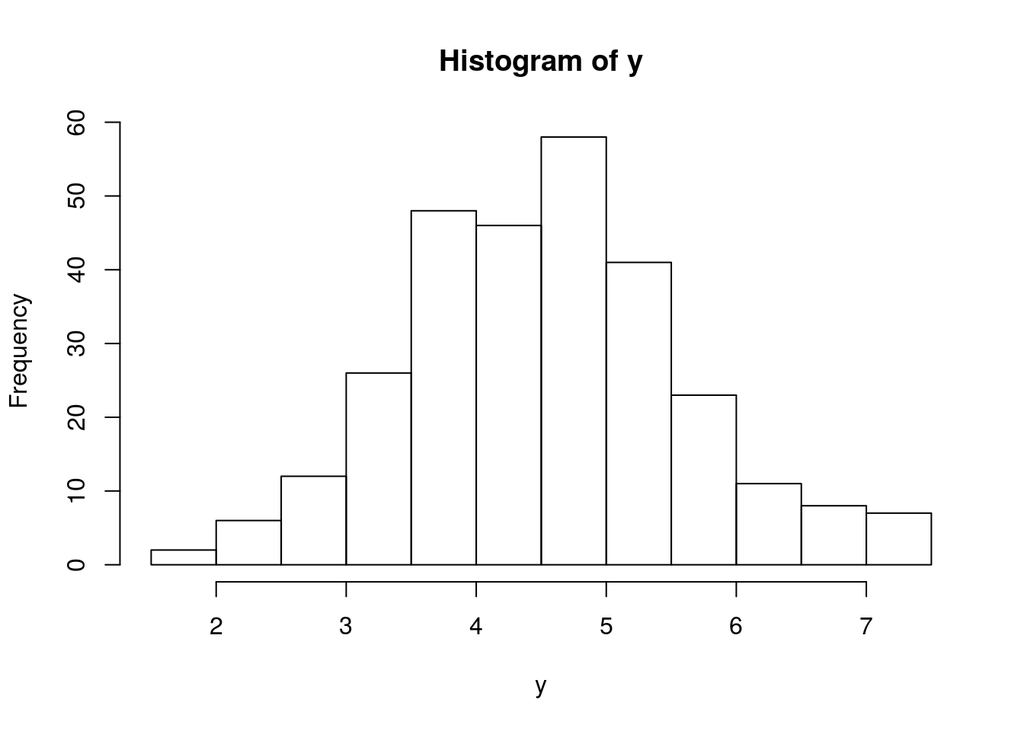

```r
attach(ow)
hist(y)
```

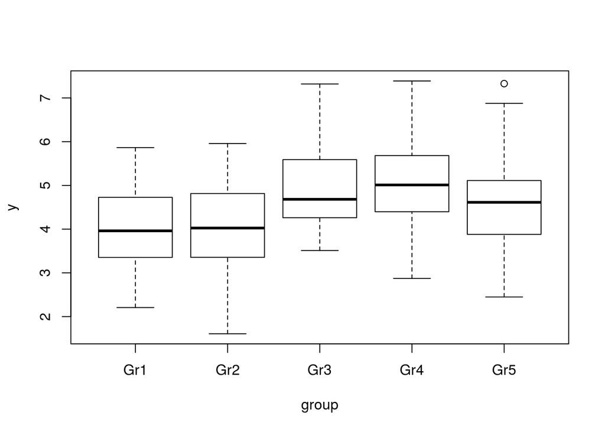

```r
plot(y ~ group)
```

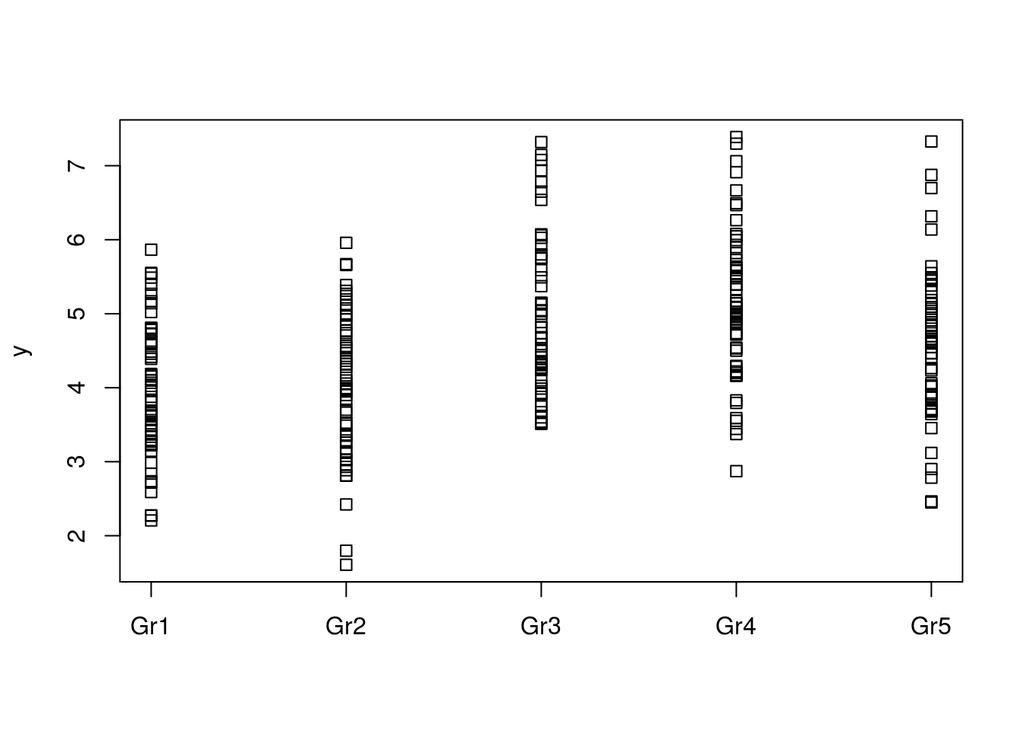

```r
stripchart(y ~ group, vertical=TRUE)
```